# R data pre-processing

Jake Ryland Williams

June 7th, 2018

# Overview

## Slide navigation

- Topics are organized from left to right.
- Each topic goes into depth from top to bottom.

## Motivation

- Pre-processing starts immediately, after acquisition
- Just loading data (depending on type) can be hard
- Sometime you might not be aware you’re doing pre-processing
- Pre-processing is often ‘glue code’, passing data from one step to another.

## Pre-processing topics

1. Objects and workspaces
   - Directory navigation
   - Data types: text, numeric, boolean
   - Characters, floats, boolean, NAs
   - Containers: ordered and associative arrays
   - Vectors, matrices, data frames, and lists

## Pre-processing topics

2. Loading/writing files
   - Saving and loading workspaces
   - Basic file i/i: really, everything text
   - Delimited files & spreadsheets
   - Complex, flexible data: JSON & XML

## Pre-processing topics

3. Interacting with files and data objects
   - Working with indices: sorting, sampling, and filtering
   - Managing names and attributes
   - Checking on files, objects, and values
   - Bringing datasets together

# Objects and workspaces

## Know your file system

- Pre-processing includes getting data in order
- Your data will live on a file hierarchy
- To see what’s in a directory, use `list.files(path)`
- To create a directory, use `dir.create(path)`
- Use `get()` and `setwd(path)` to keep instance near data
- Or just point to/from data with paths; keep instance fixed

## Filesystems

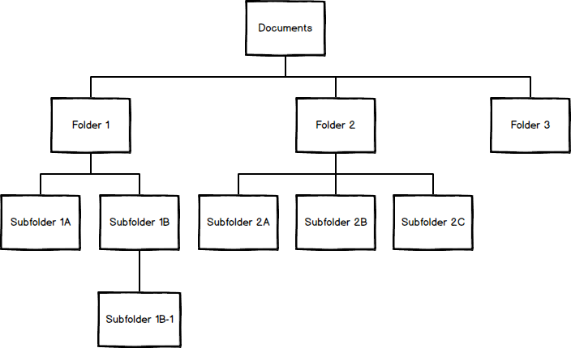

## Filesystem navigation

```
# get the current working directory
getwd()
# set the working directory
setwd(path)
# list files in a directory
print(list.files(path))
# create a new directory
dir.create.path(path)
```

## Keeping track of files and objects

- It’s helpful to know what files and objects exist
- Sometimes you also need to get of these things
- Other times you need to be careful no to overwrite!
- Use `ls()` to see what object are in a workspace
- Use `file.exists()` to see if a file exists
- Use `rm()` to remove an object from a workspace

## Workspace management

```
# view all objects in the workspace
print(ls())
# remove an object, d, from the current workspace
rm(d)
# check if file exists at path
b <- file.exists(path)
```

## Creating & navigating objects

- R has usual character, boolean, and numeric & datetime objects
- But analytic languages have hallmark container objects
- These hold different objects, and in different ways
- At a high level, we have ordered and associative arrays
- Ordered arrays store data elements through positioning
- Associative arrays utilize names/keys to store values

## Characters, numerics, and datetimes

```
# make a numeric object
x <- 2.7
print(is.numeric(x))

# make a character object
x <- "This is a character object"
print(is.characer(x))

# make some datetime objects and deltas
t1 = as.Date('1915-6-16')
print(is.numeric(t1))
t2 = as.Date('1915-8-12')
print(is.numeric.Date(t2))
tdelt <- t1 - t2
print(tdel)
print(as.double(tdelt, units = "hours")
```

## Types of ordered arrays

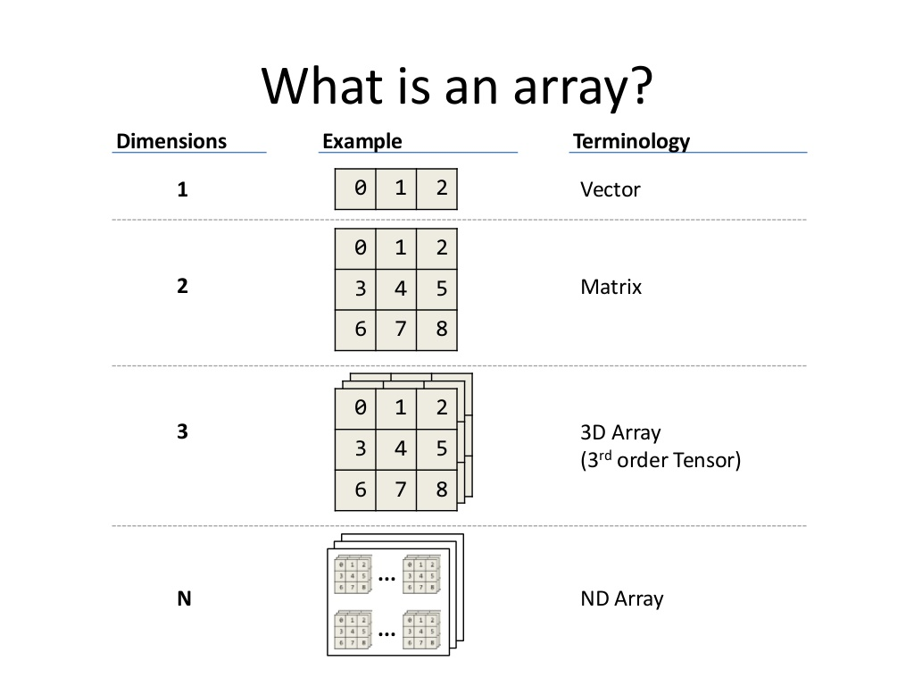

Ordered arrays

## Ordered arrays in R

- To store data in order, there are vectors and matrices

```
# make a vector and  access the second element
d <- c(x, y, z)
print(d[2])

# binding row vectors together into a matrix
M <- rbind(c(1,2,3), c(4,5,6))
# binding columns vectors together into a matrix
M <- cbind(c(1,2,3), c(4,5,6))
# access a matrix's second row, first column
print(M[2,1])
```

## Associative arrays

- Many people think of ordered arrays:data as synonymous
- But some data are more conveniently stored associatively
- Generally, associative arrays nest key-value pairs,
- allowing more flexibility/generality thank simple ordering
- But associative arrays do well to have clear schemas
- A schema is a plan/design for how to lay out data
- Associative arrays can have ordered components
- But these values are keyed for in a hierarchy.
- Structure like this should be planned out in a schema

## Schemas

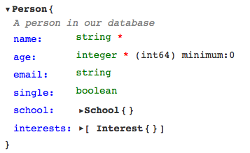

This is a schema

## R associative arrays (lists)

- Associative arrays are called “lists” in R

```
# make a list of keys and values
l <- list(
  num = 13,
  numvec = c(1,2,3),
  char = "This is a character",
  boolval = FALSE,
  mat = cbind(c(1,2,3), c(4,5,6))
)

# access a list's value by a key
print(l[['mat']])

# get keys to a list
print(names(l))
```

## But then what’s a data frame?

- Matrices are ordered arrays, but for numbers.
- Data frames are still ordered arrays,
- but they also have associative characteristics.
- They store different data types (e.g., numeric and char).
- Also, they can have row and column names for access.
- You can use these names like `list()` names.
- Note: loaded spreadsheets are generally data frames

## Data frames

```
# make a heterogeneous ordered array (data frame)
d <- data.frame(rbind(c(1,2,3), c('a', 'b', 'c')))

# give it some columns names
colnames(d) <- c("this", "that", "the other")

print(d)
```

# Load/writing files

## What’s a workspace?

- A workspace is a programming language’s state
- “State” means all objects, functions, & libraries
- But this means workspaces aren’t portable
- In other words, save/load workspaces for personal use
- For portability, we’ll talk about other file types

## Saving/loading workspaces

```
# save workspace
save(list=ls(), file="path/to/workspace.Rdata")

# load workspace
load("path/to/workspace.Rdata")
```

## Line-based file reading

- This is a standard feature in programming
- You save/load most data with special commands
- But any file can be read by lines
- By-line reading also helps processing scale
- Generally, there are three modes:
  - read (`'r'`): open for viewing
  - write (`'w'`): open for overwriting
  - append (`'a'`): open for extension

## Basic, line-based file i/o

```
# open a file connection in read mode
con <- file(path, 'r')
# read n lines from an open 'r'-connection
line = readLines(con, n)
# close the connection
close(con)
# open connection in write mode
con <- file(path, 'w')
# write a line of data
writeLines(line, con)
close(con)
```

## Spreadsheets (ordered arrays)

- It’s all about delimiters here
- Newlines (`'\n'`) always separate lines
- Commas (`','`), pipes (`'|'`) and tabs (`'\t'`) are common
- All flat delims. result in equiv data—which to use?
- Well, what does Excel use?
  - Excel is actually a lot more complicated!
  - It also includes formatting and formulae.
  - Also, multiple sheets make a 3-d ordered array!

## Flat spreadsheets

```
# read an ordered array
read.table(file, sep, header = TRUE)
# write an ordered array
write.table(file, sep, header = TRUE, row.names = FALSE)
```

## Excel

```
library(readxl)
# Load the nth sheet of an Excel file
d <- read_excel(file, sheet = n)
```

## Reading complex, associative data

- Two main data types for web content: XML and JSON
- JSON: A key-value protocol developed for javascript
  - looks a lot like python dictionaries or R lists
  - very cross-platform compatible; easy to work with
  - used by many tech companies to distribute data
- XML: Tags make data-containers; these can have attributes
  - since HTML $\subset$ XML, parse www pages like XML
  - many long-term databases are stored in this format
  - archaic markup a bit less easy to work with

## JSON

```
library(rjson)
# interpret json from a json character serialization
json_data = fromJSON(json_text)
# convert R object to json characer serialization
json_text = toJSON(json_data)
```

## XML

```
library(XML)
# read an XML/html document
doc <- xmlParse("path/to/file.xml")
```

## Accessing content on the web

- We can treat HTML like data, but how to get it?
- Browsers do this, but programming HTML is “scraping”.
- So to access, all we need is an HTML doc’s URL
- For data APIs the process is the same: construct a URL

## Downloading content

```
# download load web content behind URL
web_text <- paste(readLines(url), collapse="")
```

# Interacting with files and data objects

## Data integration

- Bringing data together is big for pre-processing
- Ideally, structured data can be joined, etc.
- Metadata and annotation are essential here.
- But what are other ways data can be linked, besides keys?
  - E.g., lat/lon coordinates can link data geographically
- Here, focus on joins, but think broadly about data linking

## Spreadsheet joins

```
# inner join
d_i <- merge(df1, df2)
# outer join
d_o <- merge(
    x = df1, y = df2, all = TRUE,
    by.x = "column name", by.y = "column name")
# left outer join
d_lo <- merge(
     x = df1, y = df2, all.x = TRUE,
     by.x = "column name", by.y = "column name")
# right outer join
d_ro merge(
     x = df1, y = df2, all.y = TRUE,
     by.x = "column name", by.y = "column name")
```

## Navigating objects by indices

- R is primed for ordered-array operations
- Ordered arrays are accessed via indices
- Sometimes, we want to re-order an array
- Other times it’s helpful to sample, or filter
- How do we maintain connections?
- I.e., keep a sorted array links to another intact?
- Suggestion: track indicies instead of re-ordering

## Sorting vectors

- We say sorting, but this creates sorting indices
- The data (`vec`) are unchanged,
- but you can access them in sorted order

```
# get sorting indices of a vector
ix <- order(vec, decreasing = TRUE)
```

## Sampling from vectors

- The same wisdom can be applied to sampling
- `sample()` actually draws from an object
- So, feed a indices, and sample from them
- Also, don’t forget your seeds!

```
# set a sampling seed
set.seed(42)
# get sample indices, size n
ix <- sample(1:length(x), size = n)
```

## Finding indices of matching elements (filtering)

- How doe we get the elements matchin a criterion?
- This is called filtering data.
- To filter a vector, `which()` returns matching indices
- Alternatively, vectors can take logical indexing

```
# which element indices inf v are equal to x?
ix <- which(v == x)
print(ix)
print(v[ix])

# the same, but as a logical index
bool_ix <- v == x
print(bool_ix)
print(v[bool_ix])

# an what if we want to filter a vector of character objects?
match_ix <- grep(pattern, x, value = FALSE, perl = TRUE)
```